# Bruhn_C13_3

### 表 V

4000時間飛行機の疲労寿命計算（参照：表 IV）

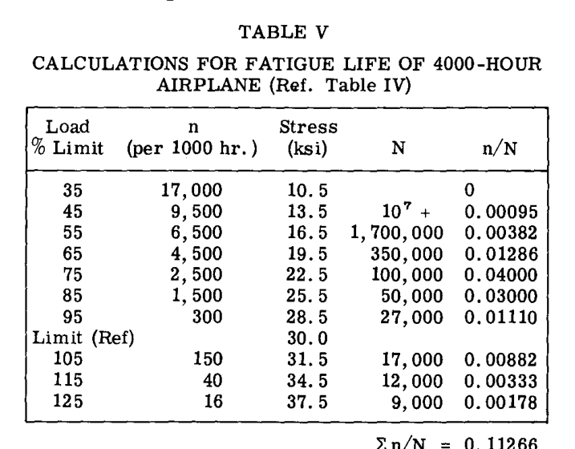

表 V

$$\Sigma n/N = 0.11266$$

$$\text{寿命} = \frac{1}{0.11266} = 8,876 \text{ 時間}$$

4のばらつき係数（スキャッターファクター）を考慮すると、計算寿命は 16,000 時間となるはずである。したがって、応力集中を低減させずには応力を下げられないと仮定すると、制限応力を 30 ksi とした我々の仮定は高すぎたことになる。現在の問題は、必要な応力低減を「推測」することである。当面の間、制限応力における応力の低下は、制限応力 30 ksi に対応する寿命（この場合は 20,000 サイクル）よりも $16,000/8,876$ 倍大きい寿命における、切欠き試験片の寿命に比例すると仮定しよう。したがって、次のようになる。

$$1.802 \times 20,000 = 36,040 \text{ サイクル}$$

これに対応する最大応力は 27.0 ksi となる。表Vに示された手順と同様の方法を用いて、寿命は約 21,000 時間と決定される。制限応力を 28 ksi および 29 ksi とした連続的な計算により、それぞれ 17,000 時間および 13,000 時間の寿命が得られた。制限応力と計算された飛行時間の関係をプロットすると、図 C13.52 に示すような直線が得られる。これより、制限荷重における許容応力は 28.3 ksi と補間される。

上記の計算はデータの出所から正当化される以上の精度を暗黙に示しているが、設計におけるばらつき係数の必要性はそこにある。契約機関にもよるが、最終的に製造された航空機は、4寿命分に相当する模擬実働荷重試験を受けなければならない。試験が何らかの不具合（たとえ軽微なものであっても）なしに完了することはほとんど期待できないが、設計者は、早期の破壊が発生した場合にどのような不利益が生じるかを認識しておく必要がある。ここでいう不利益とは、欠陥の修正コストや時間の損失を指す。したがって、設計者はヒンジブラケットのような交換可能な部品よりも、主翼スパの設計においてより保守的である必要がある。

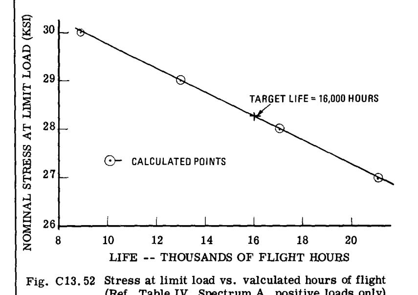

図 C13.52

上記において、利用可能な試験データに基づき $K_t = 3.1$ と仮定した。しかし、多くの航空機部品は 3.1 を大幅に超える応力集中を有しており、それより低いものもある。上記のように制限応力対寿命をプロットしたことで、任意の応力集中に対する寿命を推定できる状態になった。例えば、応力集中が 3.1 ではなく 4.0 であった場合、設計応力を $4.0 / 3.1$ の比率で単純に下げればよい。

プロットされた設計応力が直線上に乗るかどうかは、主に荷重スペクトルに依存する。しかし、どのようなスペクトルであっても、計算された寿命を図のようにプロットすることで、設計者は構造を疲労要求仕様に適合させるために必要なステップを視覚化することができる。

### 問題

表 IV のスペクトル D に従って荷重が加わる航空機の許容制限応力を求めよ。ただし、要求寿命は 50,000 時間とする。ばらつき係数を考慮した実際の寿命は 200,000 時間、 $K_t = 3.1$ , $R = 0$ （正荷重のみ）とする。

### C13.6.4 応力相互作用

図 C13.53 は、スペクトル内の上位2つの最高荷重を単に削除するだけで、特にテーパーボルトを使用した試験片において、スペクトル寿命にどれほど大きな影響を与えるかを示している。ここでは、最高荷重の2つを削除することで、テーパーボルトを使用した試験片の寿命が4倍以上に増加したのに対し、従来の締結具を使用した試験片では同様の削除によって寿命が短縮したことがわかる。

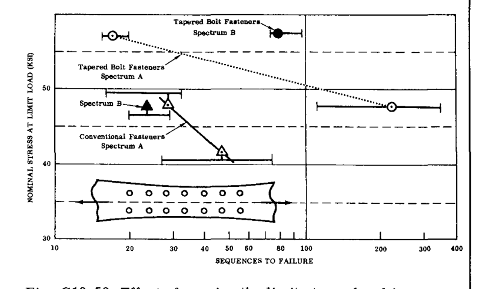

図 C13.53

### 表 VI

図 C13.53 のための荷重スペクトル（制限荷重因子の割合、100時間シーケンスあたりのサイクル数、正荷重のみ）

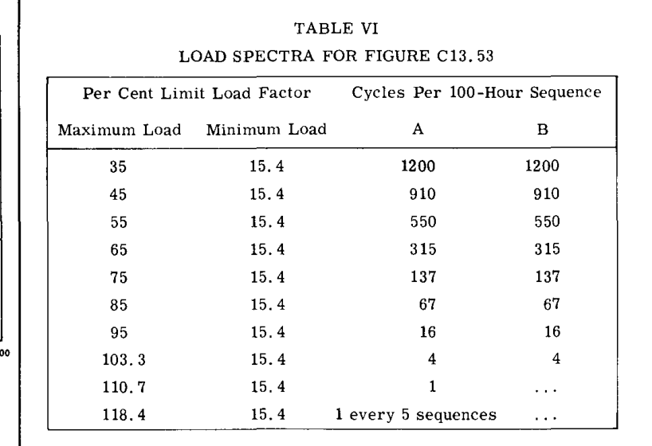

表 VI

試験片は、厚さ 0.625 インチの 7075-T651 圧延板で、複数の 1/4 インチ径の穴に無荷重のテーパーボルトまたは従来の締結具が充填されたものである。表 VI に示す試験スペクトルは、表 IV のスペクトル A とほぼ同じである。

上記における荷重は、荷重が完全には除去されていないという点で、表Vで使用されたものよりも保守的ではない。しかし、比較の目的にはこれで十分である。表Vに示された 0.11266 の全損傷を参照すると、2つの最高荷重による損傷の寄与は全体のわずか 4.5% にすぎないことがわかる。それにもかかわらず、同等の荷重を除去した結果、従来の締結具を有する試験片の寿命は低下した。直感的には、いかなる荷重であってもそれを除去すれば寿命は延びるはずだと考えられる。しかし、過大荷重によって得られる残留応力（図 C13.20 参照）を考慮すると、上記の試験結果は驚くべきことではない。これは、疲労寿命を予測する前に、構造物への高荷重の影響を予期することに対して極めて慎重である必要があることを示している。

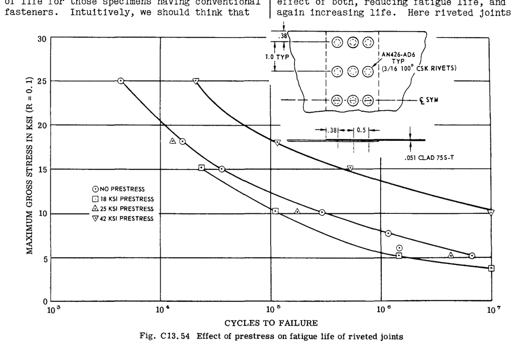

図 C13.54

応力相互作用によって生じる疲労寿命の大きな不一致を考慮すると、完全な構造物または構造部品の S-N 曲線が、そのスペクトル寿命とごくわずかしか関連していないように見える段階に達している。不一致のほとんどは、残留応力の獲得や締結具の緩みに明確に関連付けることができるが、フレッティングや腐食などの他の要因は考慮されていない。

### C13.6.5 疲労強度指数 — 簡便な解決策

静的設計の時代には、制限荷重は航空機の寿命中に決して超えられることのない荷重と考えられていた。したがって、初期の疲労試験のいくつかは、3000 〜 4000 サイクルもあれば十分な疲労要件を満たせると信じられていた、繰り返しの制限荷重を用いて行われた。図 C13.52 および図 C13.51 を再度参照すると、計算された設計制限応力 28.3 ksi は、25,000 〜 30,000 サイクルの間の寿命に対応していることがわかる。したがって、この特定のスペクトルに対して設計を行うのであれば、なぜ単に 30,000 サイクルの寿命に対して設計し、累積損傷の推定に煩わされないようにしないのだろうか？

このような設計は、構造物がスペクトル荷重試験に合格することを保証するものではないが、30,000 サイクルの制限荷重に耐えられない限り、スペクトル試験に合格する見込みは極めて薄い。これは特定の1つのスペクトルに当てはまることであるが、制限荷重におけるある寿命（疲労強度指数）は、与えられた任意のスペクトルに対する適切な寿命に対応しているはずである。

制限応力の選択がここで用いられているのは、それが静的設計の基準となるため便利だからである。さらに、実働中に発生し得る残留応力の獲得や締結具の緩みを強制的に引き起こすのに十分な高さであるべきである。

1963年（文献7）、著者は実働荷重下における構造物の疲労寿命を予測するための方法を導入した。これは、スペクトル中の最高荷重によって生じる残留応力の影響を組み込んだものである。制限荷重による応力範囲（残留応力を含む）をスペクトル中の他の荷重と按分することにより、フルスケール構造物における制限荷重での寿命とスペクトル寿命との間に良好な相関関係が確立された。ただし、この方法は小さな試験片に対してはわずかに非保守的（危険側）であった。不一致はあるものの、小さな試験片を用いた多数の試験により、少なくとも従来の締結具が使用されている場合、制限荷重における一定振幅寿命とスペクトル寿命との間の関係が確認された。

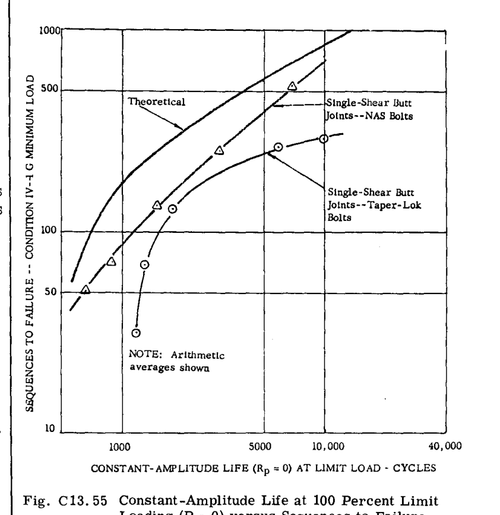

図 C13.55

試験結果を図 C13.55 に示す。ここでは、一重せん断重ね継手に対する理論曲線とグラフが、30,000 サイクルの一定振幅寿命で交差することがわかる。この場合、設計寿命と実際の寿命が一致することになる。しかし、テーパーボルトを使用した試験片の曲線は同様の挙動を示さない。図 C13.53 における挙動から予想されるように、これらはスペクトル中の高荷重に対して非常に敏感である。また、スペクトルに対するそれらの低い位置は、彼らのスペクトル寿命が低かったからではなく、彼ら自身の一定振幅寿命に対するスペクトル寿命の比率が低かったためである。なお、グラフは一定振幅寿命対スペクトル寿命を示している。

フルスケール構造物に対する一定振幅寿命対スペクトル寿命の関係を図 C13.56 に示す。ここでは、計算された寿命と試験寿命の間に優れた一致が見られる。この特定のケースにおける計算では、材料の応力-ひずみ曲線、および最大応力カットオフラインを含めるように再プロットされた図 C13.10 の S-N 曲線（図 C13.57 に再プロット）と併せて、制限荷重に対する構造物の寿命を使用している。

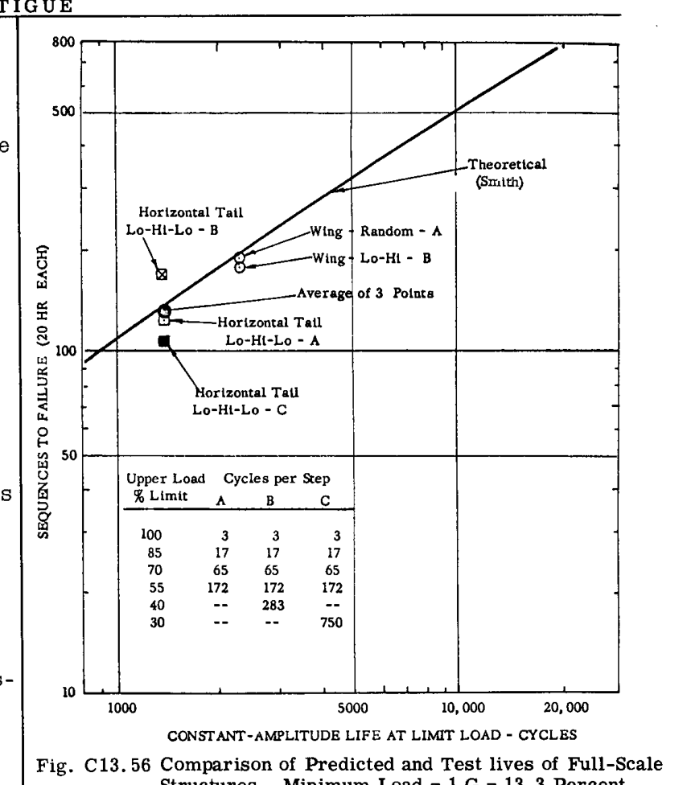

図 C13.56

ここでは、寿命が 10,000 サイクル未満の場合、応力集中部における最大応力には塑性変形が伴うと仮定している。カットオフラインの傾きは、 $R = 0.9^*$ における 3% ひずみを表す点と、 $R = 0.5$ における材料の降伏強度によって決定される。

- $R = 0.9$ は、引張降伏後に圧縮降伏が低下するバウシンガー効果のため、圧縮残留応力の限界値として選択された。3% ひずみは、応力集中係数 4 に 0.75（0.2% オフセット時のひずみ）を乗じたものに適合している。これ以上の高い歪みは、全断面積を降伏させると考えられる。

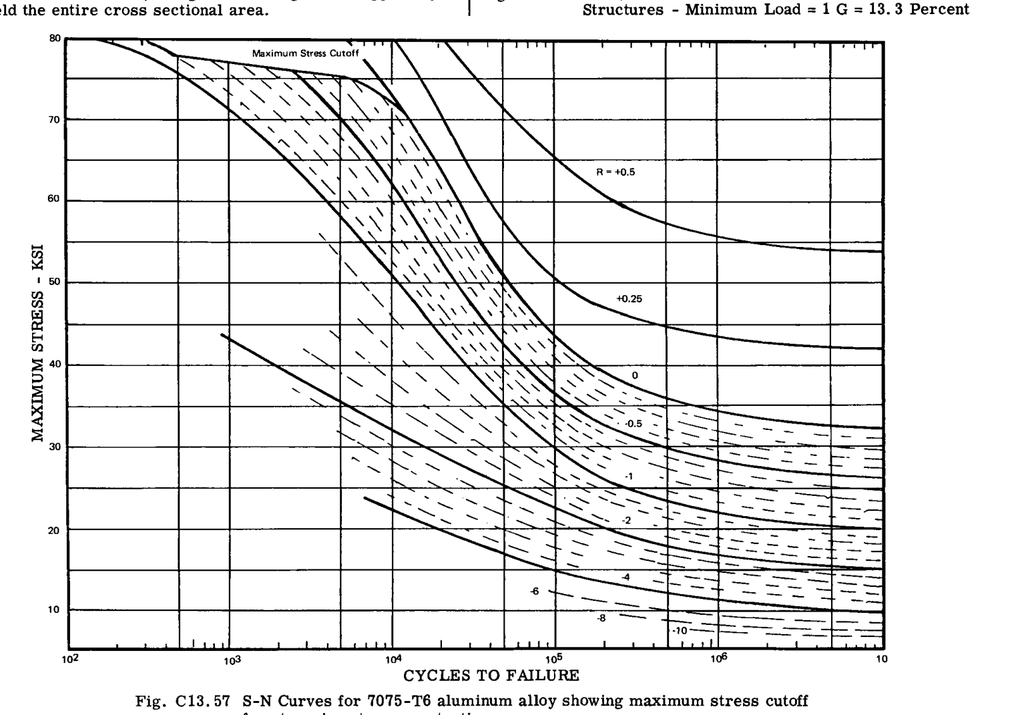

図 C13.57

そして、 $R = 0$ における 72 ksi（比例限度）の曲線と交差するようにフェアリングされる。本質的には、これは応力-ひずみ曲線の鏡像である。

したがって、航空機または構成部品が、一定振幅の引張-引張荷重を受けたときに 10,000 サイクル未満で破壊する場合、破壊点における最大応力は、寿命とカットオフラインとの交点に見出される。定義により、最小応力は、交点に存在する任意の $R$ 曲線に最大応力を乗じたものである。

最大応力と最小応力がわかれば、スペクトル内の他の任意の荷重に対して按分できる全応力範囲が得られる。公称応力も応力集中も知る必要がないことに注目されたい。

### 数値例

$R = 0$ でサイクル荷重を受け、制限荷重の 1000 サイクル後に破壊する構造物を考える。同様の構造物を以下のスペクトルに従って荷重をかけた場合、どれくらい持つだろうか？

| 制限荷重の割合 (%) | 1シーケンスあたりのサイクル数 ( $n$ ) |
| --- | --- |
| 100 | 3 |
| 85 | 17 |
| 70 | 65 |
| 55 | 172 |
| 40 | 283 |

図 C13.57 を参照すると、1000 サイクルの寿命に対応するカットオフライン上の最大応力は 77 ksi であり、交点は（補間値を使用して） $R = -0.76$ にあることがわかる。以下のスケッチを参照。

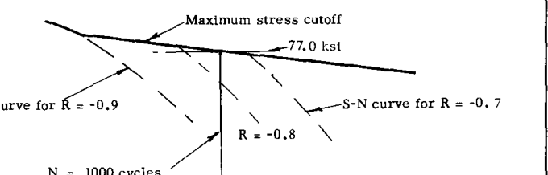

カットオフスケッチ

最小応力（ $R$ の定義より）は、 $77 \times (-0.76) = -58.5 \text{ ksi}$ となり、応力範囲は $1.76 \times 77.0 = 135.5 \text{ ksi}$ となる。

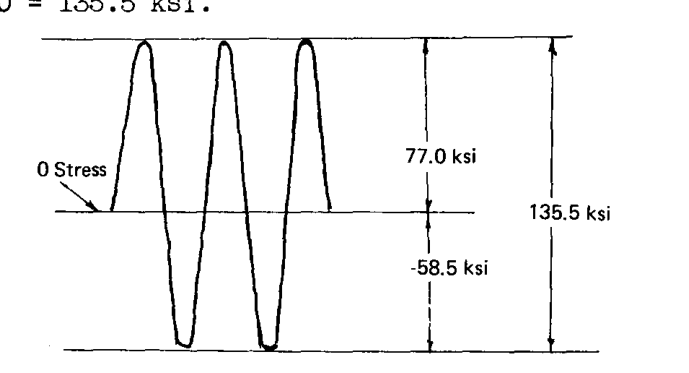

応力波形

135.5 ksi の応力範囲を用いて、スペクトル内の他の荷重に対する応力範囲を計算することができる。

| 制限荷重の割合 (%) | 応力範囲 (ksi) |
| --- | --- |
| 100 | 135.5 |
| 85 | 115.2 |
| 70 | 94.8 |
| 55 | 74.5 |
| 40 | 54.2 |

荷重順序から、最初に 100% の荷重が 3 サイクル印加されるため、 $-58.5 \text{ ksi}$ の残留応力は残りの荷重ステップ全体を通じて維持される。その後、他の荷重における最大応力を求めるために、応力範囲から残留応力が差し引かれる。

| 制限荷重の割合 (%) | 応力範囲 (ksi) | 最小応力 (ksi) | 最大応力 (ksi) |
| --- | --- | --- | --- |
| 100 | 135.5 | -58.5 | 77.0 |
| 85 | 115.2 |  | 56.7 |
| 70 | 94.8 |  | 36.3 |
| 55 | 74.5 | -58.5 | 16.0 |

これで、各荷重ステップの最大応力と最小応力が得られた。最小応力を最大応力で割ることで応力比（ $R$ ）を求め、図 C13.57 の S-N 曲線から対応する寿命（ $N$ ）を見出す。各シーケンスにおけるステップごとのサイクル数（ $n$ ）がわかれば、 $n$ を $N$ で割ることで損傷割合が求められる。構造物は、マイナー則に従い $\Sigma n/N = 1$ となったときに破壊する。すべてのステップを以下の表のように整理することで、作業が簡素化される。

[output not shown]

$$\Sigma n/N = 0.01307$$

$$\text{寿命} = \frac{1}{0.01307} = 76.5 \text{ シーケンス}$$

スミス法は一部の航空機メーカーや海軍で使用されているが、コンピュータでプログラムされていない限り計算が煩雑であり、おそらく必須ではない。スミス法がどのように機能するかをおおむね示した目的は、制限荷重における一定振幅寿命とスペクトル寿命との間の関係がどのようにして生まれたか（図 C13.56 参照）、そして実際にそのような関係が存在することを読者に理解してもらうためである。組織内の誰かが個々の航空機に対して適切な一定振幅寿命を計算する必要があるが、設計者が毎回計算を行う必要はなく、制限荷重における寿命を利用するだけで、構造がスペクトル試験に合格する十分な見込みがあるという保証を得ることができる。

前述のように、寿命予測は非常にばらつく可能性があるため、その努力が本当に必要であることはめったにない。フルスケール航空機構造物の予測と試験結果の例として、表 VII は、1つを除いてすべて線形またはマイナー則によって予測された予測値と試験結果を示している。唯一の例外（上から2番目の項目）はスミス法によって予測されたものである。

### C13.6.6 寿命予測に関するまとめ

表 VII に示す予測寿命と試験寿命の不一致を考慮すると、いかなる予測も無意味に思える段階に達している。おそらく我々は、構造物がどれくらい持つかを予測しようとするのではなく、破壊しない構造物を設計する必要性を見落としている。C13.5 に示されているように、静的強度が部品を決定するため、疲労寿命の推定が不要になるまで寿命を向上させる手段が存在する。

しかし、疲労解析は頻繁に契約上の義務の一部となっており、マイナー則は認められた方法であるため、構造物と同じ応力集中係数を持つと仮定される S-N 曲線からの寿命の単純な積分（C13.6.3 参照）が、契約上の義務を満たすことになる。しかし、フルスケール試験も契約上の義務であるため、どのような解析が行われようとも、最終的な証明は要求された模擬実働試験に耐えることにある。

構造物が要求された試験を満たすかどうかに疑問があり、応力集中がわかっている場合は、制限荷重における公称応力に応力集中を単純に乗じることで応力範囲を得ることができる。応力範囲がわかっており、それが 70 ksi を超える場合、残留応力は図 C13.58 から求めることができる。残留応力と応力範囲の差が最大応力である。応力比 $R$ は、残留応力を最大応力で割ることで得られ、適切な寿命は、累積損傷を推定するために数値例で概説されたものと同じ手順を用いて、図 C13.57 に示す S-N 曲線から見出すことができる。

### 表 VII

疲労寿命サマリー

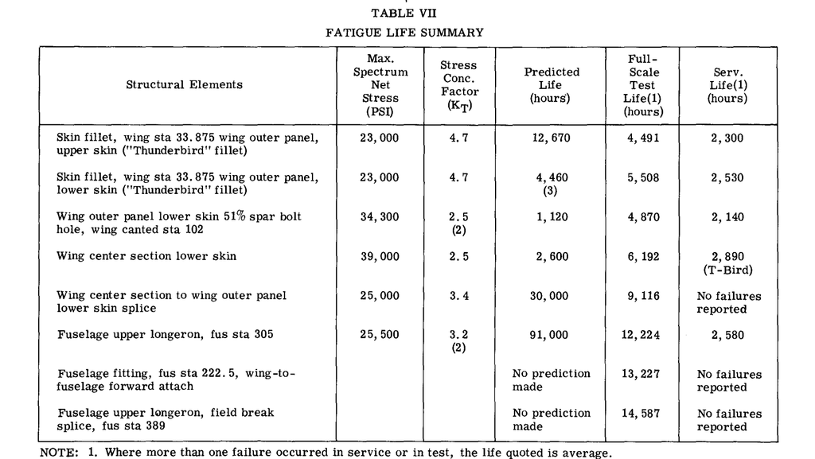

表 VII

### C13.7 セーフライフ、フェイルスロー、およびフェイルセーフ

### C13.7.1 セーフライフと亀裂進展

これまでは、寿命を延ばす方法と寿命を推定する方法について議論してきた。信頼性への唯一の拠り所が解析と模擬実働疲労試験によるものである構造は「セーフライフ（安全寿命）」と呼ばれる。このような構造は、航空機が認定された飛行時間に明確に制限される。

一重スパのビスカウトは、セーフライフ航空機の例である。言うまでもなく、このような場合には慎重な解析と徹底的な試験が必要である。しかし、一重スパ構造であっても、通常、検査手順は疲労亀裂が致命的になるずっと前に検出できるようになっている。致命的なセクションにおける亀裂の進展は疲労試験中に測定されるため、実用中の航空機に同様の亀裂が発生した場合、致命的な破壊が発生する前に十分な警告が得られる。破壊力学における最近の研究により、多くの状況における亀裂許容度を推定する方法が明らかにされている。

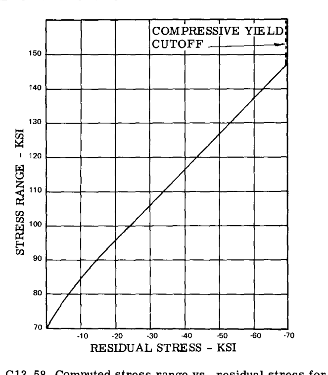

図 C13.58

最後に、実働寿命を確実に予測する方法はないが、適切な応力集中を持つ未切欠き試験片データを使用することで、これまでに考案されたどの方法よりも予測に近づくことができる。この理由は、公表されている切欠きデータの多くに、試験片の製造に起因する隠れた残留応力が含まれており、これが非保守的な推定につながるためである（C13.3.2 参照）。

一般に、薄いスキンは、厚いスキンよりも疲労亀裂による致命的な破壊の影響を受けにくい。したがって、民間航空会社は、修理が必要になるまでの許容亀裂長さについて、薄いスキンに対する標準的な方針を設けている。このような修理の通常の手順は、ストップドリル（亀裂の先端に穴を開ける）を行って亀裂を止め、同等厚さの材料のパッチでスキンを補修することである。あいにく、このような修理は一時的なものにすぎず、亀裂はいずれストップドリル穴を突き抜け、パッチの下から進行する。これは、ストップドリル穴が実際には亀裂の先端を完全に取り込んでいなかったためであると一般に信じられている。

Grover (45) は、亀裂の成長を4つの段階に分けて考えている。第1段階は単純に発生、第2段階は成長の初期段階、第3段階は安定成長段階（伝播研究で通常測定されるもの）、そして最後に急速伝播の段階である。段階間の全時間は応力に依存するが、荷重が一定振幅である場合、すべての応力レベルにおいて段階間の比率はほぼ同じである。スペクトル中の高荷重は局所的な降伏を引き起こし、その後の低荷重において短期間の遅延効果をもたらす。

ストップドリル穴の有効性を判断するために、亀裂の端に直径 3/16 インチの穴を開ける第2の実験が行われた。試験片は 51,000 サイクル持ち（図 C13.59、グラフ b 参照）、これは全寿命の 20% の延長に相当する。さらに2つの実験が行われ、1つはストップドリル穴にストレスピン（図 C13.38 参照）を打ち込んだもの、もう1つは亀裂を 3/8 インチ成長させた後に、亀裂の 1/16 インチが締結具の頭部を超えて延びるようにストレスピンを挿入して、ストップドリル穴が亀裂の先端を逃したケースを模擬したものである。これらは図 C13.59 のグラフ (c) および (d) に示されている。ここでは、亀裂ストップ穴に締結具を使用することで、5倍以上の寿命向上が達成されることがわかる。この理由は、締結具の突出したフランジが亀裂を横断して荷重を伝達するブリッジとして機能し、多かれ少なかれ亀裂をまたいでホッチキスの針が打ち込まれたかのようになるためである。

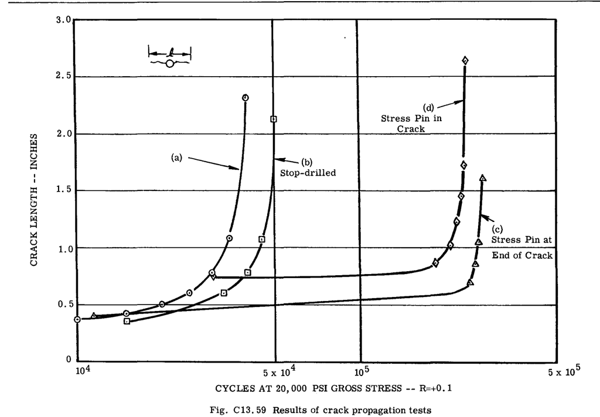

図 C13.59

### C13.7.2 フェイルセーフ

構造物がそのいわゆる保証寿命の前に破壊しないことを保証する確実な方法はないため、現在では、多数の荷重伝達部材のいずれか1つが破壊した場合でも、航空機が破壊することなく設計制限荷重の保証された割合を依然として担うことができるように、複数の荷重経路を提供することが一般的な実務となっている。したがって、5本のスパを持つ主翼は、1本のスパを完全に失っても、元の設計荷重の 80% を依然として担うことができる。これは比喩的な表現であり、どのスパが破壊したかによって、ねじり剛性はスパの数に比例しない可能性がある。

フェイルセーフラグを持つシステムは、それらを積層（ラミネート）し、ラミネートの1つが破壊しても残りの強度に影響を与えないようにすることである。これは、亀裂が一定の深さ、例えば1つのラミネートの厚さまで進行することを許容し、破壊靭性が支配的な特徴となるフェイルスローの考え方とは多少異なる。換言すれば、亀裂が入ったラグの残存領域の強度は、その定格 $P/A$ 値のわずかな割合にすぎない。これは亀裂が入ったスキンにも当てはまるが、薄いスキンは厚いプレートよりも大きな破壊靭性を持っている。Wilhelm (46) は、厚さが 0.15 インチ未満のスキンは、厚さが 0.80 インチを超える場合よりも 2.4 倍タフであることを示している。

補強材（スチフナー）とスキンの組み合わせを使用することは、航空機のフェイルセーフの健全性を高める。それは複数の荷重経路を提供するだけでなく、ストリンガーが亀裂停止装置（クラックアレスター）として機能するためである。すなわち、亀裂はストリンガーまで進行し、次のストリンガーへ進む前に一定期間、伝播を停止する。これはフェイルセーフというよりはフェイルスローである。いずれにせよ、亀裂が危険になる前に修理を行うための時間的猶予を与える。

インテグラル燃料タンクは、ある意味でフェイルセーフな特徴を備えている。これは、燃料の漏洩によって、従来の検査プロセスで検出されるよりもずっと前に亀裂が明らかになるという事実に起因している。

亀裂の緩慢な進展は、ある意味でフェイルセーフな手段を構成するが、亀裂の修理に多くの時間を費やす余裕のある航空会社はない。これは修理コスト自体の問題だけでなく、航空機のダウンタイムのためでもある。700万ドルの航空機が使用されない場合の毎日の金利は、6% の利率を仮定すると、1日あたり 1,150 ドルに達する。したがって、たとえフェイルセーフな特徴が備わっていたとしても、亀裂の発生を防ぐことが最も重要であることがわかる。

## C13.8 頻繁に見落とされる問題領域

### C13.8.1 圧縮面の疲労破壊

航空機構造は疲労と静的要件の両方に対して設計されなければならないが、通常の慣行は静的強度に対して設計し、その後、構造を疲労強度まで引き上げるために必要なことを行うことである。しかし、疲労問題のため、最近の傾向は、主翼下面、尾翼面、および胴体構造に対して、より強度の低い材料（2024-T3）を使用することである。2024-T3（または T851）は、7075 合金よりも亀裂進展速度が遅く、また脆性破壊靭性が高い。

主に圧縮荷重を受ける上面およびその他の部材は、通常、高い圧縮降伏強度を持つため、7075-T6 または 2014-T6 材料で設計される。しかし、荷重が主に圧縮であるからといって、構造が疲労問題から免除されるわけではない。負の機動、突風、または着陸状態による引張応力は、通常、下面における対応する応力よりもはるかに小さいため、主翼上面の疲労亀裂は驚きをもたらす可能性がある。何が起こるかというと、高い正の荷重が圧縮の応力集中部で材料を降伏させ、残留引張応力を導入することである（引張で示された例のちょうど逆）。その結果、構造物が除荷されるたびに応力集中部が引張応力を受けることになる。

最終的に疲労亀裂が発生し、亀裂の面積がそれ以上の降伏なしに圧縮荷重を担うのに十分になるまで進行する。それ以降は、負の荷重のみが亀裂長さを増加させる。しかし、脆性破壊特性のため、このような構造は、たとえどんなに小さな荷重であっても、負の荷重に対して危険なものとなる。したがって、正の荷重のみを伴う疲労試験では欠陥が明らかにならない可能性があり、残留応力を考慮しない限り解析も同様である。

圧縮面における破壊は、通常、フィレット、締結具の穴、またはアクセスドアの角で発生する。対策は、寛大なフィレット（図 C13.46 〜 48 参照）を使用するか、締結具の穴を完全に充填することである。干渉適合が最善であるが、現在、取り外し可能なパネルに対して満足のいく干渉適合締結具は存在しない。厚いスキンでは、鋭い面取り（100°の代わりに 60°）を持つ皿頭締結具を使用することが可能であり、これにより、取り付け時に締結具の頭部が、穴における塑性流動を許容することなく、要求される圧縮荷重を担うことができる。

スキンが薄すぎて 60° の皿頭を許容できず、干渉適合締結具を使用することが不可能な場合は、最大許容クリアランスのガイドラインとして以下を使用すべきである。7075 または 2014 合金において塑性変形を引き起こすにはわずか 0.006 インチ/インチのひずみ（比例限度）しか必要とせず、広い板の穴に対する応力集中係数は 3 であるため、穴における圧縮塑性流動の危険を冒す前の、直径 1 インチのボルトに対する最大クリアランスは $0.006 / 3 = 0.002 \text{ インチ}$ となる。同様に、直径 1/4 インチのボルトのクリアランスは 0.0005 インチ以下でなければならない。圧縮面に低強度の合金を使用する場合は、比例限度の違いに比例して許容差を縮小しなければならない。

### C13.8.2 応力を受ける部品への重い鍛造品の取り付け

鍛造品自体は、好ましくない結晶粒方向に荷重がかかることがあるため、時として疲労を起こしやすいが、それらは頻繁に高度に応力を受ける部品に取り付けられ、応力を受ける部材の応力パターンとは何の関係もないとされているにもかかわらず、早期の疲労破壊の触媒となる。この例は、応力を受けるスパウェブを介して主翼バルクヘッドに取り付けられた重いサポートブラケットである（図 C13.60 参照）。ここで疲労亀裂は、鍛造品を主翼バルクヘッドに取り付けるために使用された締結具から開始された。しかし、それはスパウェブが適切に変形することを許容せず、示されているような結果をもたらした。

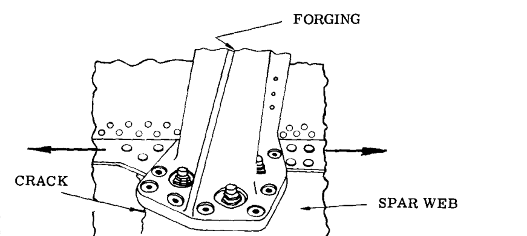

図 C13.60